# Проект: A/B-тест для крупного интернет-магазина

**Цель исследования**  
Испытать гипотезы, созданные совместно с отделом маркетинга крупного интернет-магазина, запустить A/B-тест и проанализировать результаты.

**План**

1. Импортировать данные и провести обработку(чистка от пропусков, преобразование типов столбцов)
2. Провести приоритизацию гипотез через фреймворки ICE и RICE
3. Провести анализ A/B-теста
4. Вывод и решения по A/B-тесту.

```python
import pandas as pd
import numpy as np
from datetime import datetime, timedelta
from matplotlib import pyplot as plt
import scipy.stats as stats
```

## Подготовка данных

### Загрузка данных, проверка на пропуски и дубликаты

```python
hypothesis, orders, visitors = (
    pd.read_csv('/datasets/hypothesis.csv'),
    pd.read_csv('/datasets/orders.csv'),
    pd.read_csv('/datasets/visitors.csv')
)

data_tables = {'hypothesis': hypothesis, 'orders': orders, 'visitors': visitors}

def data_preparation_func(data):
    for name, i in data.items():
        print(f"\033[1mИнформация по таблице {name}:\033[0m")
        i.info()
        duplicates = i.duplicated().sum()
        print(f"\033[1mКоличество дубликатов в таблице {name}:\033[1m {duplicates}\n")

data_preparation_func(data_tables)
```

```
Информация по таблице hypothesis:
<class 'pandas.core.frame.DataFrame'>
RangeIndex: 9 entries, 0 to 8
Data columns (total 5 columns):
 #   Column      Non-Null Count  Dtype
---  ------      --------------  -----
 0   Hypothesis  9 non-null      object
 1   Reach       9 non-null      int64
 2   Impact      9 non-null      int64
 3   Confidence  9 non-null      int64
 4   Efforts     9 non-null      int64
dtypes: int64(4), object(1)
memory usage: 488.0+ bytes
Количество дубликатов в таблице hypothesis: 0

Информация по таблице orders:
<class 'pandas.core.frame.DataFrame'>
RangeIndex: 1197 entries, 0 to 1196
Data columns (total 5 columns):
 #   Column         Non-Null Count  Dtype
---  ------         --------------  -----
 0   transactionId  1197 non-null   int64
 1   visitorId      1197 non-null   int64
 2   date           1197 non-null   object
 3   revenue        1197 non-null   int64
 4   group          1197 non-null   object
dtypes: int64(3), object(2)
memory usage: 46.9+ KB
Количество дубликатов в таблице orders: 0

Информация по таблице visitors:
<class 'pandas.core.frame.DataFrame'>
RangeIndex: 62 entries, 0 to 61
Data columns (total 3 columns):
 #   Column    Non-Null Count  Dtype
---  ------    --------------  -----
 0   date      62 non-null     object
 1   group     62 non-null     object
 2   visitors  62 non-null     int64
dtypes: int64(1), object(2)
memory usage: 1.6+ KB
Количество дубликатов в таблице visitors: 0
```

### Описание данных

**Таблица hypothesis содержит следующие данные:**

- *Hypothesis* — краткое описание гипотезы, тип данных: object;
- *Reach* — охват пользователей по 10-балльной шкале, тип данных: int64;
- *Impact* — влияние на пользователей по 10-балльной шкале, тип данных: int64;
- *Confidence* — уверенность в гипотезе по 10-балльной шкале, тип данных: int64;
- *Efforts* — затраты ресурсов на проверку гипотезы по 10-балльной шкале. Чем больше значение Efforts, тем дороже проверка гипотезы, тип данных: int64.

**Таблица orders содержит следующие данные:**

- *transactionId* — идентификатор заказа, тип данных: int64;
- *visitorId* — идентификатор пользователя, совершившего заказ, тип данных: int64;
- *date* — дата, когда был совершён заказ, тип данных: object, тип данных неверный для даты, нужно заменить на datetime64[ns];
- *revenue* — выручка заказа, тип данных: int64;
- *group* — группа A/B-теста, в которую попал заказ, тип данных: object.

**Таблица visitors содержит следующие данные:**

- *date* — дата, тип данных: object;
- *group* — группа A/B-теста, тип данных: object;
- *visitors* — количество пользователей в указанную дату в указанной группе A/B-теста, тип данных: int64.

### Преобразуем типы данных в столбцах

Столбцы на замену  
**orders:**

- *date* — дата, когда был совершён заказ, тип данных: object, тип данных неверный для даты, нужно заменить на datetime64[ns];

**visitors:**

- *date* — дата, когда был совершён заказ, тип данных: object, тип данных неверный для даты, нужно заменить на datetime64[ns];

```python
orders['date'] = pd.to_datetime(orders['date'])
visitors['date'] = pd.to_datetime(visitors['date'])
```

```python
print(orders.dtypes)
print(visitors.dtypes)
```

```
transactionId             int64
visitorId                 int64
date             datetime64[ns]
revenue                   int64
group                    object
dtype: object
date        datetime64[ns]
group               object
visitors             int64
dtype: object
```

### Переименование колонок

```python
hypothesis.columns = hypothesis.columns.str.lower().str.replace(' ', '_')
print(hypothesis.columns)
```

```
Index(['hypothesis', 'reach', 'impact', 'confidence', 'efforts'], dtype='object')
```

### Дополнительные сведения

```python
# Количество групп в АВ-тесте
print(f'Виды групп: {orders["group"].unique()}\n')
```

```
Виды групп: ['B' 'A']
```

```python
# Даты начала и конца теста
print(f'Начало теста: {orders["date"].min()}\n')
print(f'Конец теста: {orders["date"].max()}')
```

```
Начало теста: 2019-08-01 00:00:00

Конец теста: 2019-08-31 00:00:00
```

```python
# Количество уникальных пользователей по каждой группе
users_per_group = orders.groupby('group')['visitorId'].nunique().reset_index()
users_per_group.columns = ['группа', 'уникальные пользователи']
users_per_group
```

|  | группа | уникальные пользователи |
| --- | --- | --- |
| 0 | A | 503 |
| 1 | B | 586 |

```python
# Пользователи в обоих группах
users_in_both_groups = orders.groupby('visitorId')['group'].nunique().reset_index()
users_in_both_groups = users_in_both_groups[users_in_both_groups['group'] > 1]
users_in_both_groups.count()
```

```
visitorId    58
group        58
dtype: int64
```

```python
# Удалим их и выведем результат
orders = orders[~orders['visitorId'].isin(users_in_both_groups['visitorId'])]
users_per_group = orders.groupby('group')['visitorId'].nunique().reset_index()
users_per_group.columns = ['группа', 'уникальные пользователи']
users_per_group
```

|  | группа | уникальные пользователи |
| --- | --- | --- |
| 0 | A | 445 |
| 1 | B | 528 |

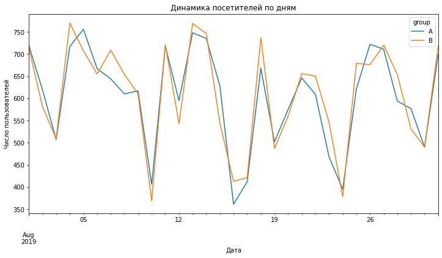

```python
# Динамика посетителей по дням по группам
visitors_by_day = visitors.groupby(['date', 'group'])['visitors'].sum().unstack().fillna(0)

visitors_by_day.plot(figsize=(12, 6), title='Динамика посетителей по дням')
plt.xlabel('Дата')
plt.ylabel('Число пользователей')
plt.show()
```

> Динамика у обоих групп очень схожа и практически не расходится в течение месяца

### Мини итог

- Были импортированы данные для анализа, таблицы: **hypothesis, orders и visitors**;
- Проведена обработка(чистка от пропусков, проверка на дубликаты, преобразование типов данных столбцов(для orders и visitors):  
  **date** — дата, когда был совершён заказ, тип данных: object, тип данных неверный для даты, нужно заменить на datetime64[ns].
- Переименованны колонок по стилю **snake case**
- Дата **начала теста: 2019-08-01 00:00:00, дата конца теста: 2019-08-31 00:00:00**
- Количество уникальных пользователей после фильтрации на одинаковых пользователей между группами разнится: **группа А - 445 пользователей, группа В - 528**
- Динамика у обеих групп схожа

## Приоритизация гипотез.

```python
# для полного вывода гипотез
pd.set_option('display.max_colwidth', None)
pd.set_option('display.max_columns', None)
pd.set_option('display.expand_frame_repr', False)
```

### ICE

```python
hypothesis['ICE'] = round((hypothesis['impact']*hypothesis['confidence'])/hypothesis['efforts'], 2)
hypothesis_ICE = hypothesis[['hypothesis', 'ICE']].sort_values(by=['ICE'], ascending=False)
display(hypothesis_ICE)
print(f"\n\033[1mТоп приоритетных гипотез по фреймворку ICE:\033[0m \n{hypothesis_ICE['hypothesis'][:5]}\n")
```

|  | hypothesis | ICE |
| --- | --- | --- |
| 8 | Запустить акцию, дающую скидку на товар в день рождения | 16.20 |
| 0 | Добавить два новых канала привлечения трафика, что позволит привлекать на 30% больше пользователей | 13.33 |
| 7 | Добавить форму подписки на все основные страницы, чтобы собрать базу клиентов для email-рассылок | 11.20 |
| 6 | Показать на главной странице баннеры с актуальными акциями и распродажами, чтобы увеличить конверсию | 8.00 |
| 2 | Добавить блоки рекомендаций товаров на сайт интернет магазина, чтобы повысить конверсию и средний чек заказа | 7.00 |
| 1 | Запустить собственную службу доставки, что сократит срок доставки заказов | 2.00 |
| 5 | Добавить страницу отзывов клиентов о магазине, что позволит увеличить количество заказов | 1.33 |
| 3 | Изменить структура категорий, что увеличит конверсию, т.к. пользователи быстрее найдут нужный товар | 1.12 |
| 4 | Изменить цвет фона главной страницы, чтобы увеличить вовлеченность пользователей | 1.00 |

```
Топ приоритетных гипотез по фреймворку ICE:
8                                                         Запустить акцию, дающую скидку на товар в день рождения
0              Добавить два новых канала привлечения трафика, что позволит привлекать на 30% больше пользователей
7                Добавить форму подписки на все основные страницы, чтобы собрать базу клиентов для email-рассылок
6            Показать на главной странице баннеры с актуальными акциями и распродажами, чтобы увеличить конверсию
2    Добавить блоки рекомендаций товаров на сайт интернет магазина, чтобы повысить конверсию и средний чек заказа
Name: hypothesis, dtype: object
```

### RICE

```python
hypothesis['RICE'] = (hypothesis['reach']*hypothesis['impact']*hypothesis['confidence'])/hypothesis['efforts']
hypothesis_RICE = hypothesis[['hypothesis', 'RICE']].sort_values(by=['RICE'], ascending=False)
display(hypothesis_RICE)
print(f"\n\033[1mТоп приоритетных гипотез по фреймворку RICE:\033[0m \n{hypothesis_RICE['hypothesis'][:5]}\n")
```

|  | hypothesis | RICE |
| --- | --- | --- |
| 7 | Добавить форму подписки на все основные страницы, чтобы собрать базу клиентов для email-рассылок | 112.0 |
| 2 | Добавить блоки рекомендаций товаров на сайт интернет магазина, чтобы повысить конверсию и средний чек заказа | 56.0 |
| 0 | Добавить два новых канала привлечения трафика, что позволит привлекать на 30% больше пользователей | 40.0 |
| 6 | Показать на главной странице баннеры с актуальными акциями и распродажами, чтобы увеличить конверсию | 40.0 |
| 8 | Запустить акцию, дающую скидку на товар в день рождения | 16.2 |
| 3 | Изменить структура категорий, что увеличит конверсию, т.к. пользователи быстрее найдут нужный товар | 9.0 |
| 1 | Запустить собственную службу доставки, что сократит срок доставки заказов | 4.0 |
| 5 | Добавить страницу отзывов клиентов о магазине, что позволит увеличить количество заказов | 4.0 |
| 4 | Изменить цвет фона главной страницы, чтобы увеличить вовлеченность пользователей | 3.0 |

```
Топ приоритетных гипотез по фреймворку RICE:
7                Добавить форму подписки на все основные страницы, чтобы собрать базу клиентов для email-рассылок
2    Добавить блоки рекомендаций товаров на сайт интернет магазина, чтобы повысить конверсию и средний чек заказа
0              Добавить два новых канала привлечения трафика, что позволит привлекать на 30% больше пользователей
6            Показать на главной странице баннеры с актуальными акциями и распродажами, чтобы увеличить конверсию
8                                                         Запустить акцию, дающую скидку на товар в день рождения
Name: hypothesis, dtype: object
```

### Мини итог

Два использованных фреймворка показали разные результаты приоритизации гипотез.

- Самые приоритетные гипотезы в соответствии с **ICE**:
1. "Запустить акцию, дающую скидку на товар в день рождения" - 16.20 очков
2. "Добавить два новых канала привлечения трафика, что позволит привлекать на 30% больше пользователей" - 13.33 очков
3. "Добавить форму подписки на все основные страницы, чтобы собрать базу клиентов для email-рассылок" - 11.20 очков
4. "Показать на главной странице баннеры с актуальными акциями и распродажами, чтобы увеличить конверсию" - 8.00 очков
5. "Добавить блоки рекомендаций товаров на сайт интернет магазина, чтобы повысить конверсию и средний чек заказа" - 7.00
- Самые приоритетные гипотезы в соответствии с **RICE**:
1. "Добавить форму подписки на все основные страницы, чтобы собрать базу клиентов для email-рассылок" - 112.0 очков
2. "Добавить блоки рекомендаций товаров на сайт интернет магазина, чтобы повысить конверсию и средний чек заказа" - 56.0 очков
3. "Добавить два новых канала привлечения трафика, что позволит привлекать на 30% больше пользователей" - 40.0 очков
4. "Показать на главной странице баннеры с актуальными акциями и распродажами, чтобы увеличить конверсию" - 40.0 очков
5. "Запустить акцию, дающую скидку на товар в день рождения" - 16.2 очков

> Разница в приоритете из-за того, что в фреймворке **RICE** дополнительно используется показатель **REACH**, который отвечает за оценку охвата пользователей. Соответственно, правильней будет использовать именно приоритетные гипотезы по **RICE**

## Анализ A/B-теста

### График кумулятивной выручки по группам

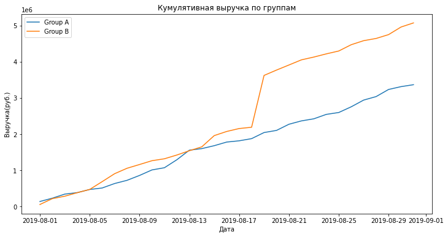

```python
cum_revenue = orders.groupby(['date', 'group']).agg({'revenue': 'sum'}).groupby('group').cumsum().reset_index()

plt.figure(figsize=(12, 6))
for group in cum_revenue['group'].unique():
    plt.plot(cum_revenue[cum_revenue['group'] == group]['date'],
             cum_revenue[cum_revenue['group'] == group]['revenue'],
             label=f'Group {group}')
plt.title('Кумулятивная выручка по группам')
plt.xlabel('Дата')
plt.ylabel('Выручка(руб.)')
plt.legend()
plt.show()
```

> На графике отчетливо видно, что с **18 августа выручка по группе B сильно скакнула вверх**, соответственно объем кумулятивной выручки по группе B сильно прибавился, но дальше она **продолжила расти в одном темпе с группой А**. Возможно, это произошло либо **из-за роста среднего чека, либо из-за увеличения количества заказов в этот период.**

### График кумулятивного среднего чека по группам.

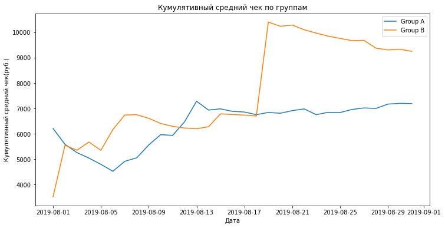

```python
cum_orders = orders.groupby(['date', 'group']).agg({'transactionId': 'count'}).groupby('group').cumsum().reset_index()

cum_data = cum_revenue.merge(cum_orders, on=['date', 'group'])

cum_data['average_order_value'] = cum_data['revenue'] / cum_data['transactionId']

plt.figure(figsize=(12, 6))
for group in cum_data['group'].unique():
    plt.plot(cum_data[cum_data['group'] == group]['date'],
             cum_data[cum_data['group'] == group]['average_order_value'],
             label=f'Group {group}')
plt.title('Кумулятивный средний чек по группам')
plt.xlabel('Дата')
plt.ylabel('Кумулятивный средний чек(руб.)')
plt.legend()
plt.show()
```

> Из графика видно, что до 18 августа средний чек по группам колебался, то есть первенство было то у группы А то у группы В. Однако **18 августа средний чек группы В резко вырос примерно до 10000 рублей**. Несмотря на такой скачок, средний чек этой группы продолжает снижаться, а средний чек группы А стабилизировался.

### График относительного изменения кумулятивного среднего чека группы B к группе A

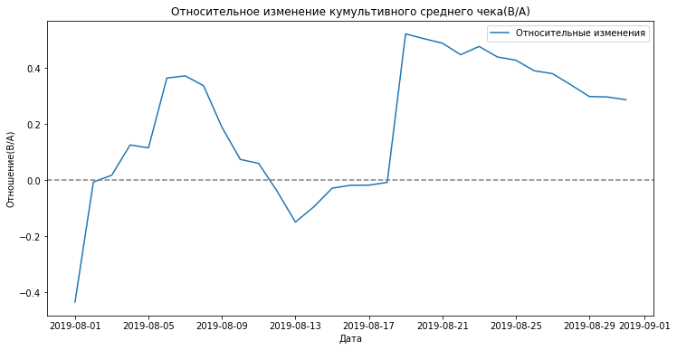

```python
pivot_data = cum_data.pivot(index='date', columns='group', values=['revenue', 'transactionId', 'average_order_value'])

relative_change = pivot_data['average_order_value']['B'] / pivot_data['average_order_value']['A'] - 1

plt.figure(figsize=(12, 6))
plt.plot(relative_change.index, relative_change, label='Относительные изменения')
plt.axhline(y=0, color='grey', linestyle='--')
plt.title('Относительное изменение кумультивного среднего чека(B/A)')
plt.xlabel('Дата')
plt.ylabel('Отношение(B/A)')
plt.legend()
plt.show()
```

> Несмотря на резкие колебания отношения изменения кумулятивного среднего чека, **группа B показала себя лучше.** Скорее всего, 8 августа **пользователи группы В узнали о грядущем событии 18 августа и перестали много покупать**, готовясь к событию, соответственно из-за этого и были такие резкие колебания.

### График кумулятивного среднего количества заказов на посетителя по группам

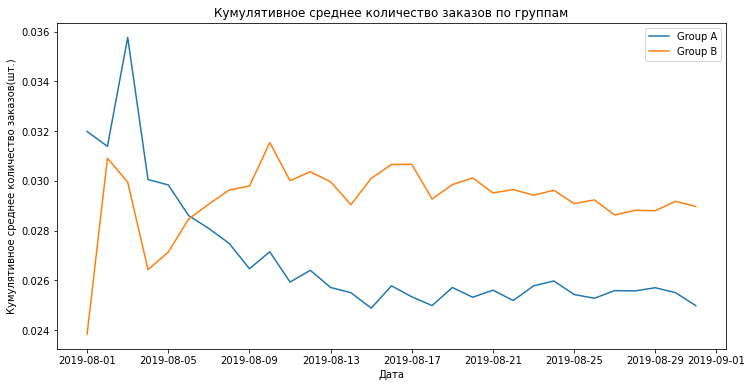

```python
cum_visitors = visitors.groupby(['date', 'group']).agg({'visitors': 'sum'}).groupby('group').cumsum().reset_index()

cum_orders_visitors = cum_orders.merge(cum_visitors, on=['date', 'group'])

cum_orders_visitors['average_orders_per_visitor'] = cum_orders_visitors['transactionId'] / cum_orders_visitors['visitors']

plt.figure(figsize=(12, 6))
for group in cum_orders_visitors['group'].unique():
    plt.plot(cum_orders_visitors[cum_orders_visitors['group'] == group]['date'],
             cum_orders_visitors[cum_orders_visitors['group'] == group]['average_orders_per_visitor'],
             label=f'Group {group}')
plt.title('Кумулятивное среднее количество заказов по группам')
plt.xlabel('Дата')
plt.ylabel('Кумулятивное среднее количество заказов(шт.)')
plt.legend()
plt.show()
```

> Количество заказов по группам сильно не меняется: **группа В обогнала группу А в количестве заказов 6 августа, и с этого момента среднее количество заказов группы В сильно выше.** Возможно для группы В были **добавлены блоки рекомендаций товаров на сайте интернет магазина, что повысило количество заказов на сайте.**

### График относительного изменения кумулятивного среднего количества заказов на посетителя группы B к группе A

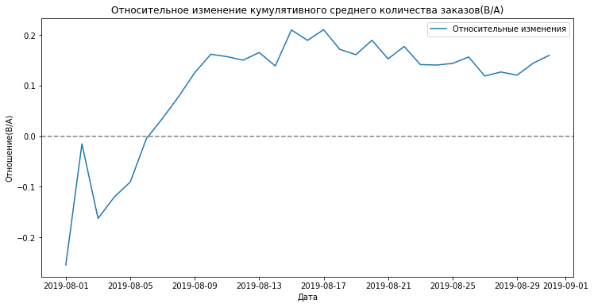

```python
pivot_orders = cum_orders_visitors.pivot(index='date', columns='group', values='average_orders_per_visitor')

rel_change_orders = pivot_orders['B'] / pivot_orders['A'] - 1

plt.figure(figsize=(12, 6))
plt.plot(rel_change_orders.index, rel_change_orders, label='Относительные изменения')
plt.axhline(y=0, color='grey', linestyle='--')
plt.title('Относительное изменение кумулятивного среднего количества заказов(B/A)')
plt.xlabel('Дата')
plt.ylabel('Отношение(B/A)')
plt.legend()
plt.show()
```

> Среднее **количество заказов группы В стабильно сильно выше**, начиная с 6 августа.

### Точечный график количества заказов по пользователям

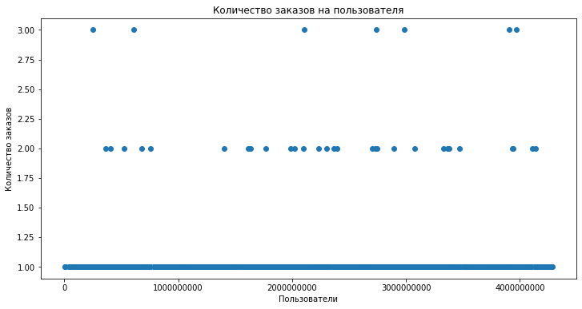

```python
orders_by_visitors = orders.groupby('visitorId').agg({'transactionId': 'count'}).reset_index()

plt.figure(figsize=(12, 6))
plt.ticklabel_format(style='plain')
plt.scatter(x= orders_by_visitors['visitorId'], y = orders_by_visitors['transactionId'])
plt.title('Количество заказов на пользователя')
plt.xlabel('Пользователи')
plt.ylabel('Количество заказов')
plt.show()
```

> **Среднее количество заказов для нормального пользователя 1-2 товара**. Все, что **выше 2 заказов - единичные случаи**, которые стоит исключить при проверке гипотез.

### 95-й и 99-й перцентили количества заказов на пользователя

```python
print(np.percentile(orders_by_visitors['transactionId'], [95,99]))
```

```
[1. 2.]
```

> Только у **5% пользователей заказов больше 1, и только у 1% - больше 2**. Соответственно, при анализе стоит **исключить тех пользователей, у которых больше 2 заказов, чтобы не урезая много данных, добиться статистической точности**.

### Точечный график стоимостей заказов

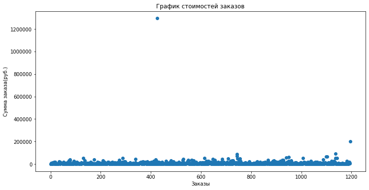

```python
plt.figure(figsize=(12, 6))
plt.ticklabel_format(style='plain')
plt.scatter(orders.index, orders['revenue'])
plt.title('График стоимостей заказов')
plt.xlabel('Заказы')
plt.ylabel('Сумма заказа(руб.)')
plt.show()
```

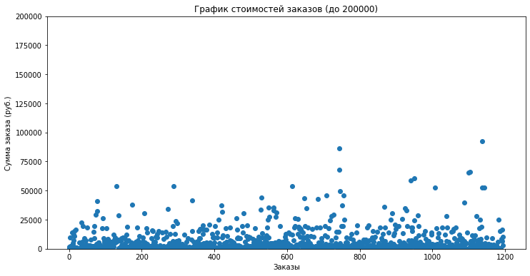

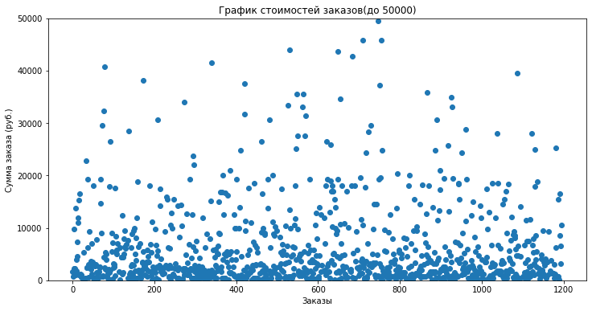

```python
plt.figure(figsize=(12, 6))
plt.ticklabel_format(style='plain')
plt.scatter(orders.index, orders['revenue'])
plt.ylim(0, 200000)
plt.title('График стоимостей заказов (до 200000)')
plt.xlabel('Заказы')
plt.ylabel('Сумма заказа (руб.)')
plt.show()

plt.figure(figsize=(12, 6))
plt.ticklabel_format(style='plain')
plt.scatter(orders.index, orders['revenue'])
plt.ylim(0, 50000)
plt.title('График стоимостей заказов(до 50000)')
plt.xlabel('Заказы')
plt.ylabel('Сумма заказа (руб.)')
plt.show()
```

> Не учитывая выбросы, **основная часть заказов имеет стоимость до 20-25 тыс. руб.**

### 95-й и 99-й перцентили стоимости заказов

```python
print(np.percentile(orders['revenue'], [95,99]))
```

```
[26785. 53904.]
```

### Статистическая значимость различий в среднем количестве заказов на посетителя между группами по «сырым» данным

**H_0:** Среднее количество заказов пользователей группы А равно среднему количеству заказов пользователей группы В.

$H_0: \mu_{заказы\ группы\ А} = \mu_{заказы\ группы\ В}$

**H_1:** Среднее количество заказов пользователей группы А не равно среднему количеству заказов пользователей группы В.

$H_1: \mu_{заказы\ группы\ А} \neq \mu_{заказы\ группы\ В}$

```python
ordersByUsersA = (
    orders[orders['group'] == 'A']
    .groupby('visitorId', as_index=False)
    .agg({'transactionId': pd.Series.nunique})
)
ordersByUsersA.columns = ['visitorId', 'orders']

ordersByUsersB = (
    orders[orders['group'] == 'B']
    .groupby('visitorId', as_index=False)
    .agg({'transactionId': pd.Series.nunique})
)
ordersByUsersB.columns = ['visitorId', 'orders']

visitorsA_ids = orders[orders['group'] == 'A']['visitorId'].unique()
visitorsB_ids = orders[orders['group'] == 'B']['visitorId'].unique()

ordersByUsersA = pd.concat([ordersByUsersA['orders'],pd.Series(0, index=np.arange(visitors[visitors['group']=='A']['visitors'].sum() - len(ordersByUsersA['orders'])), name='orders')],axis=0)
ordersByUsersB = pd.concat([ordersByUsersB['orders'],pd.Series(0, index=np.arange(visitors[visitors['group']=='B']['visitors'].sum() - len(ordersByUsersB['orders'])), name='orders')],axis=0)

ordersByUsersA = pd.DataFrame(ordersByUsersA)
ordersByUsersA.columns = ['orders']
ordersByUsersB = pd.DataFrame(ordersByUsersB)
ordersByUsersB.columns = ['orders']

p_value_raw_orders = stats.mannwhitneyu(ordersByUsersA['orders'], ordersByUsersB['orders'])[1]
mean_diff_raw_orders = ordersByUsersB['orders'].mean() / ordersByUsersA['orders'].mean() - 1

p_value_raw_orders, mean_diff_raw_orders
print("p-value: {0:.3f}".format(p_value_raw_orders))
print("Относительное изменение: {0:.3f}".format(mean_diff_raw_orders))
```

```
p-value: 0.011
Относительное изменение: 0.160
```

- Значение p-value меньше 0.05, что означает, что мы можем отвергнуть нулевую гипотезу. Таким образом, **статистически значимые различия в среднем количестве заказов на посетителя между группами А и В есть.**
- Относительное изменение = 0.160, что означает, что **группа B имеет на 16% больше заказов на посетителя по сравнению с группой A, что является весомым аргументом в эффективность группы B.

### Статистическая значимость различий в среднем чеке заказа между группами по «сырым» данным

**H_0:** Средний чек заказа пользователей группы А равен среднему чеку заказов пользователей группы В.

$H_0: \mu_{заказы\ группы\ А} = \mu_{заказы\ группы\ В}$

**H_1:** Средний чек заказа пользователей группы А не равен среднему чеку заказов пользователей группы В.

$H_1: \mu_{заказы\ группы\ А} \neq \mu_{заказы\ группы\ В}$

```python
p_value_raw_revenue = stats.mannwhitneyu(orders[orders['group'] == 'A']['revenue'], orders[orders['group'] == 'B']['revenue'])[1]
mean_diff_raw_revenue = orders[orders['group'] == 'B']['revenue'].mean() / orders[orders['group'] == 'A']['revenue'].mean() - 1

print("p-value: {0:.3f}".format(p_value_raw_revenue))
print("Относительное изменение: {0:.3f}".format(mean_diff_raw_revenue))
```

```
p-value: 0.829
Относительное изменение: 0.287
```

### Статистическая значимость различий в среднем количестве заказов на посетителя между группами по «очищенным» данным

**H_0:** Среднее количество заказов пользователей группы А по "очищенным" данным равно среднему количеству заказов пользователей группы В по "очищенным" данным .

$H_0: \mu_{заказы\ группы\ А} = \mu_{заказы\ группы\ В}$

**H_1:** Среднее количество заказов пользователей группы А по "очищенным" данным не равно среднему количеству заказов пользователей группы В по "очищенным" данным.

$H_1: \mu_{заказы\ группы\ А} \neq \mu_{заказы\ группы\ В}$

```python
ordersByUsersA = (
    orders[orders['group'] == 'A']
    .groupby('visitorId', as_index=False)
    .agg({'transactionId': pd.Series.nunique})
)
ordersByUsersA.columns = ['visitorId', 'orders']

ordersByUsersB = (
    orders[orders['group'] == 'B']
    .groupby('visitorId', as_index=False)
    .agg({'transactionId': pd.Series.nunique})
)
ordersByUsersB.columns = ['visitorId', 'orders']

ordersByUsers = pd.concat([ordersByUsersA, ordersByUsersB])


sampleA = pd.concat([ordersByUsersA['orders'],pd.Series(0, index=np.arange(visitors[visitors['group']=='A']['visitors'].sum() - len(ordersByUsersA['orders'])), name='orders')],axis=0)
sampleB = pd.concat([ordersByUsersA['orders'],pd.Series(0, index=np.arange(visitors[visitors['group']=='A']['visitors'].sum() - len(ordersByUsersA['orders'])), name='orders')],axis=0)

usersWithManyOrders = pd.concat(
    [
        ordersByUsersA[ordersByUsersA['orders'] > 2]['visitorId'],
        ordersByUsersB[ordersByUsersB['orders'] > 2]['visitorId'],
    ],
    axis=0,
)
usersWithExpensiveOrders = orders[orders['revenue'] > 28000]['visitorId']
abnormalUsers = (
    pd.concat([usersWithManyOrders, usersWithExpensiveOrders], axis=0)
    .drop_duplicates()
    .sort_values()
)
sampleAFiltered = pd.concat(
    [
        ordersByUsersA[
            np.logical_not(ordersByUsersA['visitorId'].isin(abnormalUsers))
        ]['orders'],
        pd.Series(
            0,
            index=np.arange(
                visitors[visitors['group']=='A']['visitors'].sum() - len(ordersByUsersA['orders'])
            ),
            name='orders',
        ),
    ],
    axis=0,
)

sampleBFiltered = pd.concat(
    [
        ordersByUsersB[
            np.logical_not(ordersByUsersB['visitorId'].isin(abnormalUsers))
        ]['orders'],
        pd.Series(
            0,
            index=np.arange(
                visitors[visitors['group']=='B']['visitors'].sum() - len(ordersByUsersB['orders'])
            ),
            name='orders',
        ),
    ],
    axis=0,
)

sampleAFiltered = pd.DataFrame(sampleAFiltered)
sampleAFiltered.columns = ['orders']
sampleBFiltered = pd.DataFrame(sampleBFiltered)
sampleBFiltered.columns = ['orders']


p_value_clean_orders = stats.mannwhitneyu(sampleAFiltered['orders'], sampleBFiltered['orders'])[1]
mean_diff_clean_orders = sampleBFiltered['orders'].mean() / sampleAFiltered['orders'].mean() - 1

print("p-value: {0:.3f}".format(p_value_clean_orders))
print("Относительное изменение: {0:.3f}".format(mean_diff_clean_orders))
```

```
p-value: 0.009
Относительное изменение: 0.189
```

- p-value также меньше 0.05, что означает, **что мы можем отвергнуть нулевую гипотезу и статистически значимые различия в среднем количестве заказов** на посетителя по "очищенным" данным между группами есть.
- Относительное изменение - 0.189 показывает, что **группа B имеет на 18.9% больше заказов на посетителя по сравнению с группой A, что является весомым аргументом в эффективность группы B.**

### Статистическая значимость различий в среднем чеке заказа между группами по «очищенным» данным

**H_0:** Средний чек заказа пользователей группы А по "очищенным" данным равен среднему чеку заказов пользователей группы В по "очищенным" данным.

$H_0: \mu_{заказы\ группы\ А} = \mu_{заказы\ группы\ В}$

**H_1:** Средний чек заказа пользователей группы А по "очищенным" данным не равен среднему чеку заказов пользователей группы В по "очищенным" данным.

$H_1: \mu_{заказы\ группы\ А} \neq \mu_{заказы\ группы\ В}$

```python
# Определение аномальных пользователей
ordersByUsersA = (
    orders[orders['group'] == 'A']
    .groupby('visitorId', as_index=False)
    .agg({'transactionId': pd.Series.nunique, 'revenue': 'sum'})
)
ordersByUsersA.columns = ['visitorId', 'orders', 'revenue']

ordersByUsersB = (
    orders[orders['group'] == 'B']
    .groupby('visitorId', as_index=False)
    .agg({'transactionId': pd.Series.nunique, 'revenue': 'sum'})
)
ordersByUsersB.columns = ['visitorId', 'orders', 'revenue']

ordersByUsers = pd.concat([ordersByUsersA, ordersByUsersB])

abnormalUsers = ordersByUsers[(ordersByUsers['orders'] > 2) & (ordersByUsers['revenue'] > 28000)]['visitorId']

filtered_orders_A = orders[np.logical_and(orders['group'] == 'A', np.logical_not(orders['visitorId'].isin(abnormalUsers)))]
filtered_orders_B = orders[np.logical_and(orders['group'] == 'B', np.logical_not(orders['visitorId'].isin(abnormalUsers)))]

p_value_clean_revenue = stats.mannwhitneyu(filtered_orders_A['revenue'], filtered_orders_B['revenue'])[1]
mean_diff_clean_revenue = filtered_orders_B['revenue'].mean() / filtered_orders_A['revenue'].mean() - 1

print("p-value: {0:.3f}".format(p_value_clean_revenue))
print("Относительное изменение: {0:.3f}".format(mean_diff_clean_revenue))
```

```
p-value: 0.926
Относительное изменение: 0.304
```

- p-value значительно больше 0.05, что означает, что мы не можем отвергнуть нулевую гипотезу и **статистически значимых различий в среднем чеке заказа между группами группами А и В нет.**
- **Относительное изменение - 0.304 показывает, что средний чек группы B на 30.4% больше, чем у группы A.**

### Решение по результатам теста.

> По результатам проверки стоит **остановить тест зафиксировать победу группы B.**